# Assessment

Celia Luciano Sagastume

May 4, 2018

```r
##load any librarys you may need.  tidyverse has already been loaded here for you

library("dplyr")
```

```r
library("stringr")
library("psych")
library("ggplot2")
library("readr")
library("car")
library("NonCompart")
library("plotly")
library("PK")
```

## Instructions

This is an assessment project to be completed by prospective candidates looking to apply to the Biometrics Department at Denali Therapeutics. The assessment is intended to take between 30-60 minutes to complete and is aimed at assessing required technical skills. Please feel free to include more comprehensive or alternative approaches as you deem fit. Completed report should be in html format. Please create a **new github repository** to share your work with us.

## Data

Start by loading the dataset Theoph. This is data relating to a pharmacokinetics experiment of the anti-asthmatic drug theophylline.

```r
data(Theoph)
```

To add a bit more complexity, we will introduce a hypothetical demographics dataset characterizing the subjects.

```r
##please add any corresponding data cleanup as needed
dm <- read.csv("~/Desktop/Clinical_Data_Scientist_Intern_Assessment-master/dm.csv")
str(dm)
```

```
## 'data.frame':    12 obs. of  3 variables:
##  $ SUBJECT: int  1 2 3 4 5 6 7 8 9 10 ...
##  $ SEX    : Factor w/ 4 levels "F","Female","M",..: 3 4 1 3 3 1 2 1 2 4 ...
##  $ Age    : Factor w/ 12 levels "~66 years","2200 weeks",..: 3 4 5 8 10 9 2 1 11 7 ...
```

```r
dems=dm
dems$SUBJECT=as.numeric(as.character(dems$SUBJECT))
dems<-mutate_all(dm,funs(toupper))
```

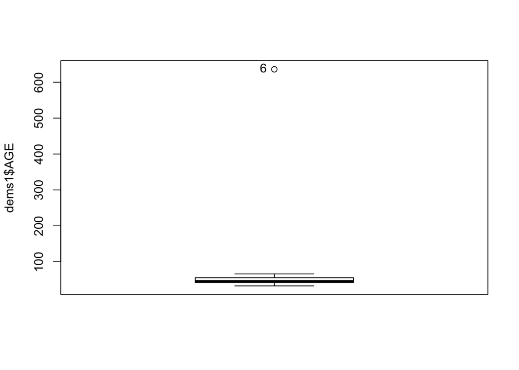

```
## [1] 6
```

```r
dems$SEX[dems$SEX == "MALE"] <- "M"
dems$SEX[dems$SEX == "FEMALE"] <- "F"
dems$AGE_TYPE<- str_extract(dems$Age,"YEAR |MONTH|YEARS|MONTHS|WEEKS")



dems1 <- dems %>%

  mutate(

    AGE_NUM = parse_number(Age))

dems1$AGE_TYPE<-gsub("YEARS",1,dems1$AGE_TYPE)
dems1$AGE_TYPE<-gsub("MONTH",12,dems1$AGE_TYPE)
dems1$AGE_TYPE<-gsub("WEEKS",52,dems1$AGE_TYPE)
dems1$AGE_TYPE[is.na(dems1$AGE_TYPE)]<-1
dems1$AGE_TYPE = as.numeric(dems1$AGE_TYPE)

dems1$AGE = (dems1$AGE_NUM) / (dems1$AGE_TYPE)
Boxplot(dems1$AGE)
```

```r
dems2 <- dems1[-c(6),]

demographics <- dems2[,c(0:2,6),]

colnames(demographics)[1]<-"Subject"

PK_data<- merge(demographics,Theoph, by = c("Subject"))
PK_dataF<- PK_data %>% mutate(SEX = factor(SEX, levels = c("F", "M"), labels = c("Female", "Male")))
colnames(PK_data)[6]<-"time"
colnames(PK_data)[1]<-"id"



PK_AUC<- PK_data %>% group_by(time) %>%  summarise( conc= mean(conc))
PK_AUC<-mutate(PK_AUC, C1_C2= lag(conc, default = 0) + conc)
PK_AUC<-mutate(PK_AUC, c_T= (time - lag(time, default = 0)))
PK_AUC<-mutate(PK_AUC, AUC_lin= ((C1_C2)/2)*c_T)
PK_AUC<-mutate(PK_AUC, AUC_tot= (AUC_lin + lag(AUC_lin, default = 0)))

PK_data$Time_Point <- cut(PK_data$time, 6, include.lowest = TRUE, labels = c(0,5,10,15,20,25))

Split_PK<-split(PK_data,PK_data$SEX)
Male_PK<-Split_PK$M
Fem_PK<-Split_PK$F

F_PK<- Fem_PK %>% group_by(time) %>%  summarise( conc= mean(conc))
F_PK<-mutate(F_PK, C1_C2= lag(conc, default = 0) + conc)
F_PK<-mutate(F_PK, c_T= (time - lag(time, default = 0)))
F_PK<-mutate(F_PK, AUC_lin= ((C1_C2)/2)*c_T)
F_PK<-mutate(F_PK, AUC_tot= (AUC_lin + lag(AUC_lin, default = 0)), Gender = "Female")


M_PK<- Male_PK %>% group_by(time) %>%  summarise( conc= mean(conc))
M_PK<-mutate(M_PK, C1_C2= lag(conc, default = 0) + conc)
M_PK<-mutate(M_PK, c_T= (time - lag(time, default = 0)))
M_PK<-mutate(M_PK, AUC_lin= ((C1_C2)/2)*c_T)
M_PK<-mutate(M_PK, AUC_tot= (AUC_lin + lag(AUC_lin, default = 0)) , Gender = "Male")
```

Please characterize and provide a summary of the data stratefied by gender.**

*Hint: Don’t forget to also include characterization of age, weight and peak concentrations.*

```r
##input characterization and summary data code here.

Dose.desc <- describeBy(PK_data$Dose,PK_data$SEX, mat = TRUE,  quant=c(.25,.75), IQR = TRUE)
Conc.desc <- describeBy(PK_data$conc,PK_data$SEX, mat = TRUE,  quant=c(.25,.75), IQR = TRUE)
Age.desc<- describeBy(PK_data$AGE,PK_data$SEX, mat = TRUE,  quant=c(.25,.75), IQR = TRUE)
Weight.desc<- describeBy(PK_data$Wt,PK_data$SEX, mat = TRUE,  quant=c(.25,.75), IQR = TRUE)

Dose.desc
```

```
##    item group1 vars  n     mean        sd median  trimmed      mad  min
## 11    1      F    1 55 4.406000 0.6839661   4.53 4.490667 0.578214 3.10
## 12    2      M    1 66 4.913333 0.6778276   4.85 4.907407 0.815430 4.02
##     max range        skew  kurtosis         se  IQR Q0.25 Q0.75
## 11 4.95  1.85 -1.20447914 -0.197073 0.09222597 0.39  4.53  4.92
## 12 5.86  1.84  0.06671013 -1.642237 0.08343481 1.10  4.40  5.50
```

```r
Conc.desc
```

```
##    item group1 vars  n     mean       sd median  trimmed      mad min
## 11    1      F    1 55 4.534727 2.519742   4.86 4.637111 2.683506   0
## 12    2      M    1 66 5.554394 3.115038   6.01 5.636481 3.461871   0
##      max range       skew  kurtosis        se    IQR Q0.25  Q0.75
## 11  9.03  9.03 -0.3470219 -1.001517 0.3397619 3.6000 3.025 6.6250
## 12 11.40 11.40 -0.2938882 -1.055363 0.3834346 5.0725 2.920 7.9925
```

```r
Age.desc
```

```
##    item group1 vars  n     mean       sd median  trimmed     mad  min  max
## 11    1      F    1 55 47.18154 9.510153  42.60 45.69966 1.03782 41.7 66.0
## 12    2      M    1 66 46.15000 9.493581  49.55 46.48333 8.89560 32.8 56.5
##    range       skew   kurtosis       se        IQR    Q0.25 Q0.75
## 11  24.3  1.4484227  0.1185062 1.282349  0.9923077 42.30769  43.3
## 12  23.7 -0.4674639 -1.5368877 1.168579 20.7000000 33.90000  54.6
```

```r
Weight.desc
```

```
##    item group1 vars  n     mean       sd median  trimmed      mad  min
## 11    1      F    1 55 71.40000 7.995392  70.50 70.48889  8.15430 64.6
## 12    2      M    1 66 66.33333 9.117293  66.45 66.16296 10.74885 54.6
##     max range      skew   kurtosis       se  IQR Q0.25 Q0.75
## 11 86.4  21.8 1.0944549 -0.3355575 1.078098  5.5  65.0  70.5
## 12 79.6  25.0 0.1021444 -1.5898622 1.122261 14.5  58.2  72.7
```

## Visualization

You need to convey the data in a presentation. Please generate figures to convey the data we have captured. Pay particular attention to showing concentration change ov, er time as this is a PK experiment. Please take time to make the figure as informative as possible. Feel free to use more than one figure if needed but bear in mind that this is a presentation so fewer figures to convey the information is a plus. Bonus points for interactivity!

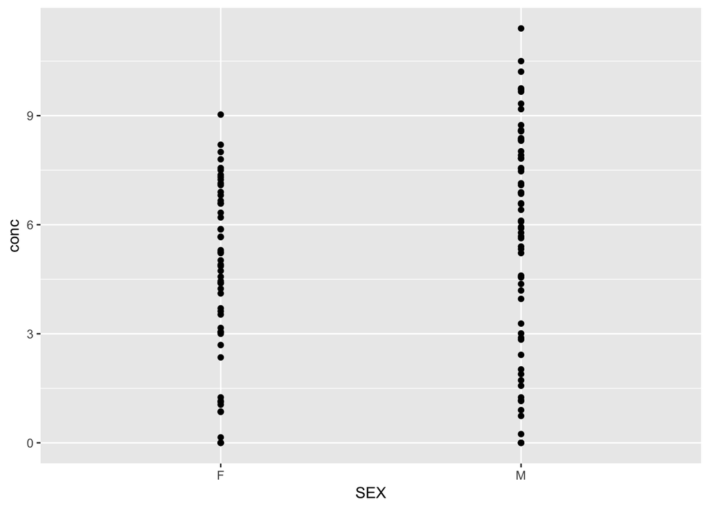

```r
##input visualization code here

ggplot(PK_data, aes(x=SEX, y=conc))+geom_point()
```

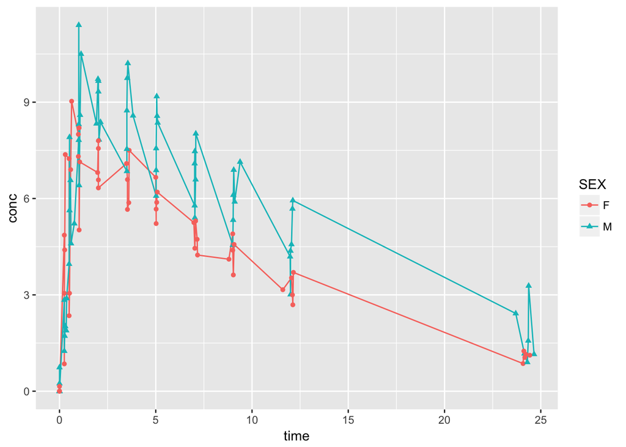

```r
ggplot(PK_data, aes(x = time, y = conc, group = SEX))   + geom_line(aes(color=SEX))+ geom_point(aes(shape=SEX, color=SEX))
```

## Analysis

Next, we would like to estimate the PK property, area under the curve (AUC), for the drug based on the available data. Please provide an **estimate** along with **associated variability**. Explain in detail any imputations or assumptions that were made.

```r
##input code for estimating AUC here.


auc(conc=PK_data$conc, time = PK_data$time, group=PK_data$SEX, method=c("t", "z", "boott"),
         alternative=c("two.sided"),
         conf.level=0.95, strata=NULL, nsample=1000,
         design=c("batch"), PK_data)
```

```
## Estimation for a batch design
##
##              Estimate    SE    95% boott-CI
## AUC to tlast   111.76 0.253 (111.76;111.76)
##
##              Estimate    SE  95% t-CI
## AUC to tlast   111.76 0.253 (NaN;NaN)
##
##              Estimate    SE        95% z-CI
## AUC to tlast   111.76 0.253 (111.27;112.26)
```